# 스타워즈 퀴즈

5주차

Author

최요한

Published

June 19, 2026

#### 0.0.0.1 Quarto

# 1 tidyverse()

```r
library(tidyverse)
```

## 1.1 starwars dataset

### 1.1.1 데이터셋 출력

##### starwars 데이터셋을 출력하고 몇 행, 몇 열인지 확인하시오

> starwars

```
# A tibble: 87 × 14
   name     height  mass hair_color skin_color eye_color birth_year sex   gender
   <chr>     <int> <dbl> <chr>      <chr>      <chr>          <dbl> <chr> <chr>
 1 Luke Sk…    172    77 blond      fair       blue            19   male  mascu…
 2 C-3PO       167    75 <NA>       gold       yellow         112   none  mascu…
 3 R2-D2        96    32 <NA>       white, bl… red             33   none  mascu…
 4 Darth V…    202   136 none       white      yellow          41.9 male  mascu…
 5 Leia Or…    150    49 brown      light      brown           19   fema… femin…
 6 Owen La…    178   120 brown, gr… light      blue            52   male  mascu…
 7 Beru Wh…    165    75 brown      light      blue            47   fema… femin…
 8 R5-D4        97    32 <NA>       white, red red             NA   none  mascu…
 9 Biggs D…    183    84 black      light      brown           24   male  mascu…
10 Obi-Wan…    182    77 auburn, w… fair       blue-gray       57   male  mascu…
# ℹ 77 more rows
# ℹ 5 more variables: homeworld <chr>, species <chr>, films <list>,
#   vehicles <list>, starships <list>
```

### 1.1.2 자료형과 구조

##### starwars 데이터셋의 자료형과 구조를 출력하시오

> str(), glimpse()

```
Rows: 87
Columns: 14
$ name       <chr> "Luke Skywalker", "C-3PO", "R2-D2", "Darth Vader", "Leia Or…
$ height     <int> 172, 167, 96, 202, 150, 178, 165, 97, 183, 182, 188, 180, 2…
$ mass       <dbl> 77.0, 75.0, 32.0, 136.0, 49.0, 120.0, 75.0, 32.0, 84.0, 77.…
$ hair_color <chr> "blond", NA, NA, "none", "brown", "brown, grey", "brown", N…
$ skin_color <chr> "fair", "gold", "white, blue", "white", "light", "light", "…
$ eye_color  <chr> "blue", "yellow", "red", "yellow", "brown", "blue", "blue",…
$ birth_year <dbl> 19.0, 112.0, 33.0, 41.9, 19.0, 52.0, 47.0, NA, 24.0, 57.0, …
$ sex        <chr> "male", "none", "none", "male", "female", "male", "female",…
$ gender     <chr> "masculine", "masculine", "masculine", "masculine", "femini…
$ homeworld  <chr> "Tatooine", "Tatooine", "Naboo", "Tatooine", "Alderaan", "T…
$ species    <chr> "Human", "Droid", "Droid", "Human", "Human", "Human", "Huma…
$ films      <list> <"A New Hope", "The Empire Strikes Back", "Return of the J…
$ vehicles   <list> <"Snowspeeder", "Imperial Speeder Bike">, <>, <>, <>, "Imp…
$ starships  <list> <"X-wing", "Imperial shuttle">, <>, <>, "TIE Advanced x1",…
```

### 1.1.3 자료 훑어보기

##### 첫 1~6행, 마지막 1~ 6행을 각각 출력하시오

> tail()

```
# A tibble: 6 × 14
  name      height  mass hair_color skin_color eye_color birth_year sex   gender
  <chr>      <int> <dbl> <chr>      <chr>      <chr>          <dbl> <chr> <chr>
1 Luke Sky…    172    77 blond      fair       blue            19   male  mascu…
2 C-3PO        167    75 <NA>       gold       yellow         112   none  mascu…
3 R2-D2         96    32 <NA>       white, bl… red             33   none  mascu…
4 Darth Va…    202   136 none       white      yellow          41.9 male  mascu…
5 Leia Org…    150    49 brown      light      brown           19   fema… femin…
6 Owen Lars    178   120 brown, gr… light      blue            52   male  mascu…
# ℹ 5 more variables: homeworld <chr>, species <chr>, films <list>,
#   vehicles <list>, starships <list>
```

```
# A tibble: 6 × 14
  name      height  mass hair_color skin_color eye_color birth_year sex   gender
  <chr>      <int> <dbl> <chr>      <chr>      <chr>          <dbl> <chr> <chr>
1 Tion Med…    206    80 none       grey       black             NA male  mascu…
2 Finn          NA    NA black      dark       dark              NA male  mascu…
3 Rey           NA    NA brown      light      hazel             NA fema… femin…
4 Poe Dame…     NA    NA brown      light      brown             NA male  mascu…
5 BB8           NA    NA none       none       black             NA none  mascu…
6 Captain …     NA    NA none       none       unknown           NA fema… femin…
# ℹ 5 more variables: homeworld <chr>, species <chr>, films <list>,
#   vehicles <list>, starships <list>
```

### 1.1.4 두개 함수 붙이기

##### 첫 1~6행, 마지막 1~ 6행을 붙여서 출력하시오

> tail()

```
# A tibble: 6 × 14
  name      height  mass hair_color skin_color eye_color birth_year sex   gender
  <chr>      <int> <dbl> <chr>      <chr>      <chr>          <dbl> <chr> <chr>
1 Luke Sky…    172    77 blond      fair       blue            19   male  mascu…
2 C-3PO        167    75 <NA>       gold       yellow         112   none  mascu…
3 R2-D2         96    32 <NA>       white, bl… red             33   none  mascu…
4 Darth Va…    202   136 none       white      yellow          41.9 male  mascu…
5 Leia Org…    150    49 brown      light      brown           19   fema… femin…
6 Owen Lars    178   120 brown, gr… light      blue            52   male  mascu…
# ℹ 5 more variables: homeworld <chr>, species <chr>, films <list>,
#   vehicles <list>, starships <list>
```

```
# A tibble: 6 × 14
  name      height  mass hair_color skin_color eye_color birth_year sex   gender
  <chr>      <int> <dbl> <chr>      <chr>      <chr>          <dbl> <chr> <chr>
1 Tion Med…    206    80 none       grey       black             NA male  mascu…
2 Finn          NA    NA black      dark       dark              NA male  mascu…
3 Rey           NA    NA brown      light      hazel             NA fema… femin…
4 Poe Dame…     NA    NA brown      light      brown             NA male  mascu…
5 BB8           NA    NA none       none       black             NA none  mascu…
6 Captain …     NA    NA none       none       unknown           NA fema… femin…
# ℹ 5 more variables: homeworld <chr>, species <chr>, films <list>,
#   vehicles <list>, starships <list>
```

### 1.1.5 개수 세기

##### 스타워즈에 등장하는 종족들을 많은 순서대로 출력하시오

> count(), species

```
# A tibble: 38 × 2
   species      n
   <chr>    <int>
 1 Human       35
 2 Droid        6
 3 <NA>         4
 4 Gungan       3
 5 Kaminoan     2
 6 Mirialan     2
 7 Twi'lek      2
 8 Wookiee      2
 9 Zabrak       2
10 Aleena       1
# ℹ 28 more rows
```

### 1.1.6 결측값

##### starwars 데이터셋의 결측값(NA)을 변수(열) 단위로 출력하시오

> colSums(), is.na()

```
      name     height       mass hair_color skin_color  eye_color birth_year
         0          6         28          5          0          0         44
       sex     gender  homeworld    species      films   vehicles  starships
         4          4         10          4          0          0          0
```

### 1.1.7 결측값 제거

##### 결측값이 하나도 없는 등장인물을 출력하시오

> drop_na()

```
# A tibble: 29 × 14
   name     height  mass hair_color skin_color eye_color birth_year sex   gender
   <chr>     <int> <dbl> <chr>      <chr>      <chr>          <dbl> <chr> <chr>
 1 Luke Sk…    172    77 blond      fair       blue            19   male  mascu…
 2 Darth V…    202   136 none       white      yellow          41.9 male  mascu…
 3 Leia Or…    150    49 brown      light      brown           19   fema… femin…
 4 Owen La…    178   120 brown, gr… light      blue            52   male  mascu…
 5 Beru Wh…    165    75 brown      light      blue            47   fema… femin…
 6 Biggs D…    183    84 black      light      brown           24   male  mascu…
 7 Obi-Wan…    182    77 auburn, w… fair       blue-gray       57   male  mascu…
 8 Anakin …    188    84 blond      fair       blue            41.9 male  mascu…
 9 Chewbac…    228   112 brown      unknown    blue           200   male  mascu…
10 Han Solo    180    80 brown      fair       brown           29   male  mascu…
# ℹ 19 more rows
# ℹ 5 more variables: homeworld <chr>, species <chr>, films <list>,
#   vehicles <list>, starships <list>
```

### 1.1.8 결측값 개수 출력

##### height, mass, homeworld 변수에 결측값이 없는 등장인물은 총 몇 명인가?

> drop_na(), , nrow()

```
[1] 56
```

### 1.1.9 범위 선택과 화면 출력

##### starwars 데이터셋에서 name, height, mass 열만 선택한 후 30개의 행을 화면에 출력하시오

> select(), print()

```
# A tibble: 87 × 3
   name                  height   mass
   <chr>                  <int>  <dbl>
 1 Luke Skywalker           172   77
 2 C-3PO                    167   75
 3 R2-D2                     96   32
 4 Darth Vader              202  136
 5 Leia Organa              150   49
 6 Owen Lars                178  120
 7 Beru Whitesun Lars       165   75
 8 R5-D4                     97   32
 9 Biggs Darklighter        183   84
10 Obi-Wan Kenobi           182   77
11 Anakin Skywalker         188   84
12 Wilhuff Tarkin           180   NA
```

[output cut: 19 more lines]

### 1.1.10 필터와 화면 출력

##### height > 180이고, mass < 50을 만족하는 등장인물의 모든 변수(열)를 화면에 출력하시오

> filter(), &, print()

```
# A tibble: 2 × 14
  name          height  mass hair_color skin_color  eye_color birth_year sex
  <chr>          <int> <dbl> <chr>      <chr>       <chr>          <dbl> <chr>
1 Padmé Amidala    185    45 brown      light       brown             46 female
2 Wat Tambor       193    48 none       green, grey unknown           NA male
  gender    homeworld species films     vehicles  starships
  <chr>     <chr>     <chr>   <list>    <list>    <list>
1 feminine  Naboo     Human   <chr [3]> <chr [0]> <chr [3]>
2 masculine Skako     Skakoan <chr [1]> <chr [0]> <chr [0]>
```

### 1.1.11 OR 조건 설정

##### “Droid”, “Dug”, “Yoda’s species” 세 종족(species)의 name, birth_year, species를 출력하시오

> filter(), %in%

```
# A tibble: 7 × 3
  name    birth_year species
  <chr>        <dbl> <chr>
1 C-3PO          112 Droid
2 R2-D2           33 Droid
3 R5-D4           NA Droid
4 IG-88           15 Droid
5 Sebulba         NA Dug
6 R4-P17          NA Droid
7 BB8             NA Droid
```

### 1.1.12 헬퍼 함수

##### color로 끝나는 변수명만 출력하시오

> select(), ends_with()

```
# A tibble: 87 × 3
   hair_color    skin_color  eye_color
   <chr>         <chr>       <chr>
 1 blond         fair        blue
 2 <NA>          gold        yellow
 3 <NA>          white, blue red
 4 none          white       yellow
 5 brown         light       brown
 6 brown, grey   light       blue
 7 brown         light       blue
 8 <NA>          white, red  red
 9 black         light       brown
10 auburn, white fair        blue-gray
# ℹ 77 more rows
```

### 1.1.13 vector 형식

##### 사회학적 성별(gender)를 vector 형식으로 출력하시오

> starwars$gender

```
 [1] "masculine" "masculine" "masculine" "masculine" "feminine"  "masculine"
 [7] "feminine"  "masculine" "masculine" "masculine" "masculine" "masculine"
[13] "masculine" "masculine" "masculine" "masculine" "masculine" NA
[19] "masculine" "masculine" "masculine" "masculine" "masculine" "masculine"
[25] "masculine" "masculine" "feminine"  "masculine" "masculine" "masculine"
[31] "masculine" "masculine" "masculine" "feminine"  "masculine" "masculine"
[37] "masculine" "masculine" "masculine" "masculine" "masculine" "feminine"
[43] "masculine" "masculine" "feminine"  "masculine" "masculine" "masculine"
[49] "masculine" "masculine" "masculine" "masculine" "masculine" "feminine"
[55] "masculine" "masculine" "masculine" "masculine" NA          NA
[61] "masculine" "masculine" "feminine"  "feminine"  "feminine"  "masculine"
[67] "masculine" "masculine" "feminine"  "masculine" "masculine" "feminine"
[73] "feminine"  "feminine"  "masculine" "masculine" "feminine"  "masculine"
[79] "masculine" "masculine" NA          "masculine" "masculine" "feminine"
[85] "masculine" "masculine" "feminine"
```

### 1.1.14 인덱싱

##### select() 함수를 사용하지 말고 10번째 행의 1번째열을 출력하시오

> [,]

```
# A tibble: 1 × 1
  name
  <chr>
1 Obi-Wan Kenobi
```

### 1.1.15 인덱싱 범위 선택

##### select() 함수를 사용하지 말고 10번째 행의 1번째열과 11번째 열을 출력하시오

> [,], c()

```
# A tibble: 1 × 2
  name           species
  <chr>          <chr>
1 Obi-Wan Kenobi Human
```

### 1.1.16 표 만들기(1)

##### table() 함수를 사용해 생물학적 성별(sex)을 도수분포표(frequency table)로 만드시오

> table(), starwars$sex

```
        female hermaphroditic           male           none
            16              1             60              6
```

### 1.1.17 표 만들기(2)

##### count() 함수를 사용해 생물학적 성별(sex)을 도수분포표(frequency table)로 만들고 위에서 만든 table() 함수 결과와 비교하시오

> count()

```
# A tibble: 5 × 2
  sex                n
  <chr>          <int>
1 male              60
2 female            16
3 none               6
4 <NA>               4
5 hermaphroditic     1
```

### 1.1.18 표 만들기(3)

##### args() 함수를 사용해 table() 함수의 인수를 확인하고 table() 함수를 사용해 count() 와 동일한 도수분포표(frequency table)로 만드시오

> args(),table(), as.data.frame(), as_tibble(), rename()

```
function (..., exclude = if (useNA == "no") c(NA, NaN), useNA = c("no",
    "ifany", "always"), dnn = list.names(...), deparse.level = 1)
NULL
```

```
# A tibble: 5 × 2
  sex             Freq
  <fct>          <int>
1 female            16
2 hermaphroditic     1
3 male              60
4 none               6
5 <NA>               4
```

### 1.1.19 표 만들기 (4)

##### 생물학적 성별이 남성(male)인 등장인물 중 최대 체중, 최소 체중 인물을 출력하시오

> filter(), arramge(), drop_na(), slice(), select()

```
# A tibble: 2 × 4
  name         height  mass species
  <chr>         <int> <dbl> <chr>
1 Ratts Tyerel     79    15 Aleena
2 Grievous        216   159 Kaleesh
```

### 1.1.20 산점도

##### starwars 데이터셋에서 height(x축)와 mass(y축)의 산점도를 그리시오 점의 색상은 gender로 구분하세요.

> ggplot(), geom_point(), aes()

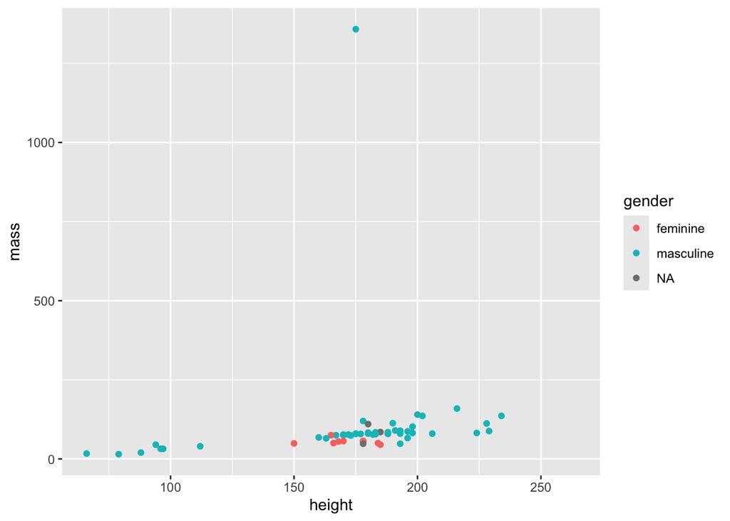

### 1.1.21 막대 그래프

##### 사회학적 성별(gender)을 기준으로 막대 그래프(geom_bar)를 시각화하고, 색깔은 생물학적 성별(sex)로 채우고 막대는 옆으로 배열하시오

> position, geom_bar()

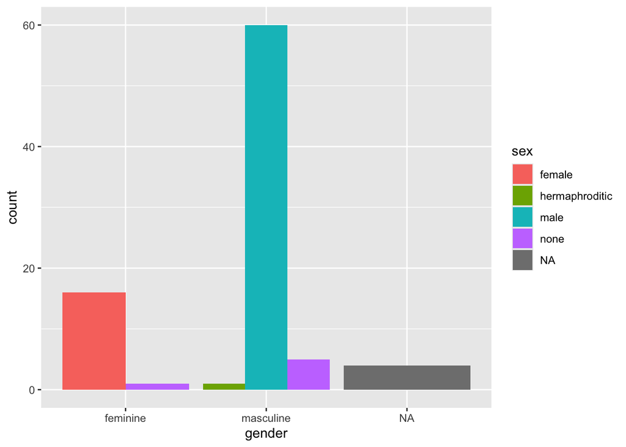

### 1.1.22 히스토그램

#### 1.1.22.1 신장(height)을 히스토그램 그래프로 시각화 하고 눈금의 넓이는 ’10’으로 하시오

> geom_historam(), binwidth = 10

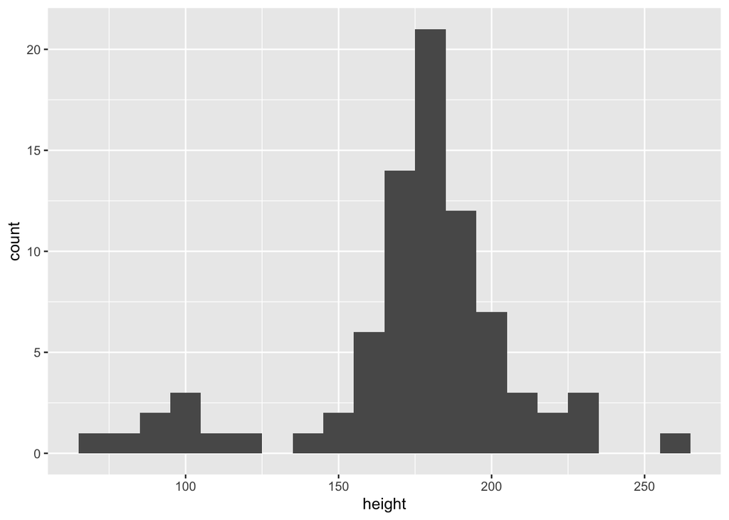

### 1.1.23 최대값과 최소값

##### 등장인물 중 가장 나이 많은 인물과 적은 인물을 출력하시오

> birth_year, arrange(), desc(), slice(), drop_na(), n()

```
# A tibble: 2 × 2
  name                  birth_year
  <chr>                      <dbl>
1 Yoda                         896
2 Wicket Systri Warrick          8
```

### 1.1.24 오름차순과 내림차순

##### name, height, birth_year를 선택한 후, 나이(birth_year)를 알수 없는 인물을 제외하고, 키가 큰 순서대로 5명을 조회하시오

> select(), birth_year, select(), arrange(), desc(), drop_na()

```
# A tibble: 5 × 3
  name          height birth_year
  <chr>          <int>      <dbl>
1 Chewbacca        228      200
2 Darth Vader      202       41.9
3 IG-88            200       15
4 Ki-Adi-Mundi     198       92
5 Jar Jar Binks    196       52
```

### 1.1.25 범위 제외

##### films, vehicles, starships 열을 제외한 나머지 모든 열을 선택하시오

> select(-), everything()

```
# A tibble: 87 × 11
   name     height  mass hair_color skin_color eye_color birth_year sex   gender
   <chr>     <int> <dbl> <chr>      <chr>      <chr>          <dbl> <chr> <chr>
 1 Luke Sk…    172    77 blond      fair       blue            19   male  mascu…
 2 C-3PO       167    75 <NA>       gold       yellow         112   none  mascu…
 3 R2-D2        96    32 <NA>       white, bl… red             33   none  mascu…
 4 Darth V…    202   136 none       white      yellow          41.9 male  mascu…
 5 Leia Or…    150    49 brown      light      brown           19   fema… femin…
 6 Owen La…    178   120 brown, gr… light      blue            52   male  mascu…
 7 Beru Wh…    165    75 brown      light      blue            47   fema… femin…
 8 R5-D4        97    32 <NA>       white, red red             NA   none  mascu…
 9 Biggs D…    183    84 black      light      brown           24   male  mascu…
10 Obi-Wan…    182    77 auburn, w… fair       blue-gray       57   male  mascu…
# ℹ 77 more rows
# ℹ 2 more variables: homeworld <chr>, species <chr>
```

### 1.1.26 파생변수 만들기

##### mass / (height/100)^2로 계산된 “bmi”라는 새로운 열을 추가하고, name, height, mass, bmi 변수만 출력하시오

> mutate(), select()

```
# A tibble: 87 × 4
   name               height  mass   bmi
   <chr>               <int> <dbl> <dbl>
 1 Luke Skywalker        172    77  26.0
 2 C-3PO                 167    75  26.9
 3 R2-D2                  96    32  34.7
 4 Darth Vader           202   136  33.3
 5 Leia Organa           150    49  21.8
 6 Owen Lars             178   120  37.9
 7 Beru Whitesun Lars    165    75  27.5
 8 R5-D4                  97    32  34.0
 9 Biggs Darklighter     183    84  25.1
10 Obi-Wan Kenobi        182    77  23.2
# ℹ 77 more rows
```

### 1.1.27 랭크 함수

##### 나이(birth_year) 많은 순서대로 순위(rank)를 부여하고 상위 10명의 name, birth_year, rank를 출력하시오 (동점자도 순위를 다르게 부여하시오)

> select(), mutate(), arrange(), filter(), row_number()

```
# A tibble: 10 × 3
   name                  birth_year  rank
   <chr>                      <dbl> <int>
 1 Yoda                         896     1
 2 Jabba Desilijic Tiure        600     2
 3 Chewbacca                    200     3
 4 C-3PO                        112     4
 5 Dooku                        102     5
 6 Qui-Gon Jinn                  92     6
 7 Ki-Adi-Mundi                  92     7
 8 Finis Valorum                 91     8
 9 Palpatine                     82     9
10 Cliegg Lars                   82    10
```

### 1.1.28 랭크 함수

##### 나이(birth_year) 많은 순서대로 순위(rank)를 부여하고 상위 10명의 name, birth_year, rank를 출력하시오 (동점자는 같은 순위를 부여하고, 차등 순위를 비우시오)

> select(), mutate(), arrange(), filter(), min_rank()

```
# A tibble: 10 × 3
   name                  birth_year  rank
   <chr>                      <dbl> <int>
 1 Yoda                         896     1
 2 Jabba Desilijic Tiure        600     2
 3 Chewbacca                    200     3
 4 C-3PO                        112     4
 5 Dooku                        102     5
 6 Qui-Gon Jinn                  92     6
 7 Ki-Adi-Mundi                  92     6
 8 Finis Valorum                 91     8
 9 Palpatine                     82     9
10 Cliegg Lars                   82     9
```

### 1.1.29 slice 함수(1)

##### 1번행, 10번행, 46번행, 56번행, 16번부터 19번행만 명시한 순서대로 출력하시오

> slice()

```
# A tibble: 8 × 14
  name      height  mass hair_color skin_color eye_color birth_year sex   gender
  <chr>      <int> <dbl> <chr>      <chr>      <chr>          <dbl> <chr> <chr>
1 Luke Sky…    172    77 blond      fair       blue              19 male  mascu…
2 Obi-Wan …    182    77 auburn, w… fair       blue-gray         57 male  mascu…
3 Ratts Ty…     79    15 none       grey, blue unknown           NA male  mascu…
4 Yarael P…    264    NA none       white      yellow            NA male  mascu…
5 Jabba De…    175  1358 <NA>       green-tan… orange           600 herm… mascu…
6 Wedge An…    170    77 brown      fair       hazel             21 male  mascu…
7 Jek Tono…    180   110 brown      fair       blue              NA <NA>  <NA>
8 Yoda          66    17 white      green      brown            896 male  mascu…
# ℹ 5 more variables: homeworld <chr>, species <chr>, films <list>,
#   vehicles <list>, starships <list>
```

### 1.1.30 slice 함수(2)

##### 10개의 행을 랜덤하게 출력하시오

> slice_sample()

```
# A tibble: 10 × 14
   name     height  mass hair_color skin_color eye_color birth_year sex   gender
   <chr>     <int> <dbl> <chr>      <chr>      <chr>          <dbl> <chr> <chr>
 1 Ric Olié    183    NA brown      fair       blue              NA male  mascu…
 2 Wicket …     88    20 brown      brown      brown              8 male  mascu…
 3 Mas Ame…    196    NA none       blue       blue              NA male  mascu…
 4 Zam Wes…    168    55 blonde     fair, gre… yellow            NA fema… femin…
 5 Bossk       190   113 none       green      red               53 male  mascu…
 6 Leia Or…    150    49 brown      light      brown             19 fema… femin…
 7 Shmi Sk…    163    NA black      fair       brown             72 fema… femin…
 8 Beru Wh…    165    75 brown      light      blue              47 fema… femin…
 9 Lobot       175    79 none       light      blue              37 male  mascu…
10 Padmé A…    185    45 brown      light      brown             46 fema… femin…
# ℹ 5 more variables: homeworld <chr>, species <chr>, films <list>,
#   vehicles <list>, starships <list>
```

### 1.1.31 slice 함수(3)

##### 등장인물 중 가장 체중(mass)이 적은 4명을 출력하시오

> slice_min(), select()

```
# A tibble: 4 × 14
  name      height  mass hair_color skin_color eye_color birth_year sex   gender
  <chr>      <int> <dbl> <chr>      <chr>      <chr>          <dbl> <chr> <chr>
1 Ratts Ty…     79    15 none       grey, blue unknown           NA male  mascu…
2 Yoda          66    17 white      green      brown            896 male  mascu…
3 Wicket S…     88    20 brown      brown      brown              8 male  mascu…
4 R2-D2         96    32 <NA>       white, bl… red               33 none  mascu…
# ℹ 5 more variables: homeworld <chr>, species <chr>, films <list>,
#   vehicles <list>, starships <list>
```

### 1.1.32 slice 함수(4)

##### 등장인물 중 가장 키(height)가 큰 8명을 출력하시오

> slice_max(), select()

```
# A tibble: 9 × 14
  name      height  mass hair_color skin_color eye_color birth_year sex   gender
  <chr>      <int> <dbl> <chr>      <chr>      <chr>          <dbl> <chr> <chr>
1 Yarael P…    264    NA none       white      yellow            NA male  mascu…
2 Tarfful      234   136 brown      brown      blue              NA male  mascu…
3 Lama Su      229    88 none       grey       black             NA male  mascu…
4 Chewbacca    228   112 brown      unknown    blue             200 male  mascu…
5 Roos Tar…    224    82 none       grey       orange            NA male  mascu…
6 Grievous     216   159 none       brown, wh… green, y…         NA male  mascu…
7 Taun We      213    NA none       grey       black             NA fema… femin…
8 Rugor Na…    206    NA none       green      orange            NA male  mascu…
9 Tion Med…    206    80 none       grey       black             NA male  mascu…
# ℹ 5 more variables: homeworld <chr>, species <chr>, films <list>,
#   vehicles <list>, starships <list>
```

### 1.1.33 반올림 하기

##### 사회학적 성별(gender)을 기준으로 등장인물수, 평균 신장, 체중을 구하고 소수 둘째자리에서 반올림 하시오

> round(), n(), filter(), group_by(), refraem(), mean()

```
# A tibble: 3 × 4
  gender    mean_height mean_mass     n
  <chr>           <dbl>     <dbl> <int>
1 feminine         166.      54.7    17
2 masculine        176.     106.     66
3 <NA>             175       81       4
```

### 1.1.34 산점도와 스케일

##### x축 = mass, y축 = height, color = sex, shape = gender 산점도를 그리시오

> ggplot(), geom_point()

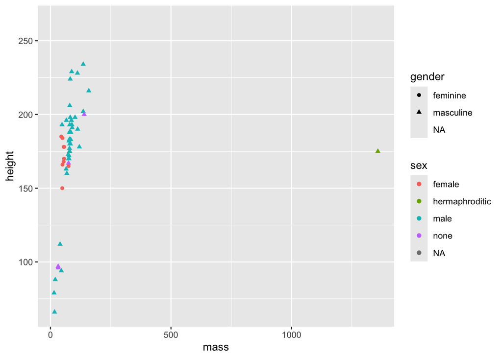

### 1.1.35 그래프 확대

##### 데이터 포인트는 size = 3으로 설정하고 위 그래프를 확대하시오 (mass > 12.5, mass =< 50, height > 60, height =< 100)

> coord_cartesian()

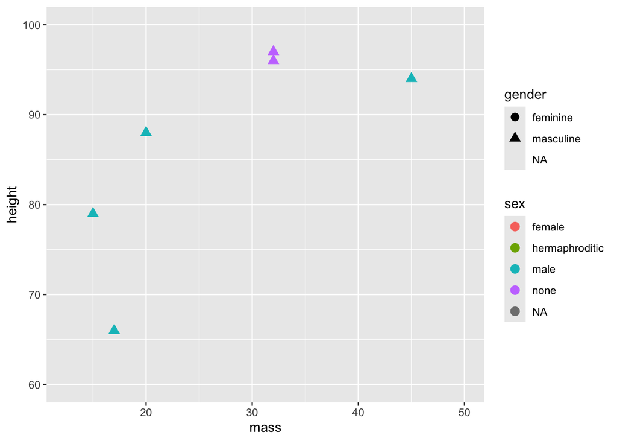

### 1.1.36 막대 그래프 (1)

> ggplot(), geom_bar(), labs()

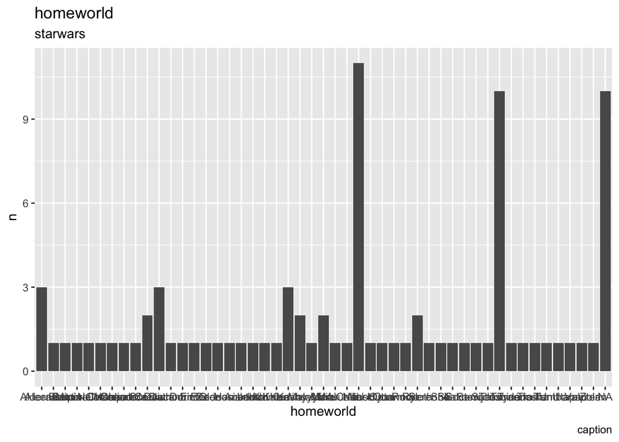

### 1.1.37 막대 그래프 (2) - 축 변환

##### 위 그래프의 x축 가독성을 높이기 위해 x,y 축변환하시오

> ggplot(), geom_point(), coord_flip()

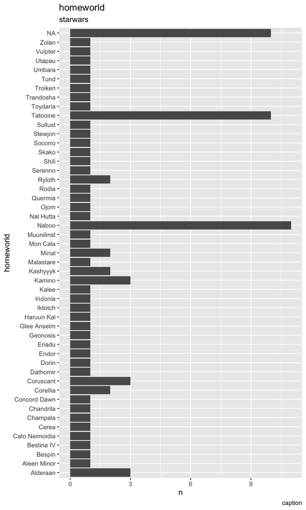

### 1.1.38 막대 그래프 (3)

##### 빈도가 높은 순서대로 정렬한 후 상위 10개의 막대만 남기고 나머지는 그래프에서 제거하시오

> ggplot(), geom_point(), fct_reorder(), desc() ggplot(aes(x = homeworld |> fct_reorder(n)

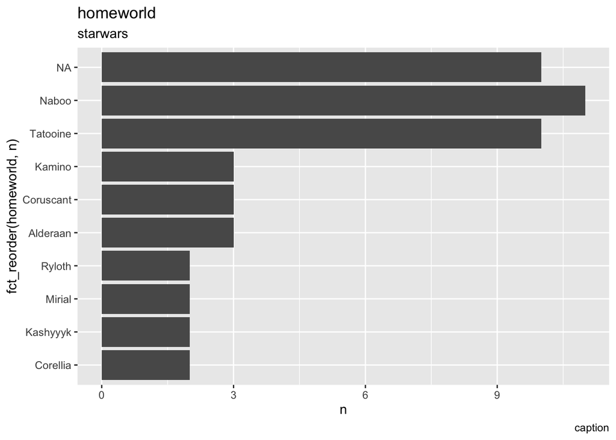

### 1.1.39 막대 그래프 (4)

##### NA를 순위에 맞게 위치시키고(내림차순), 막대에 값(label)을 붙이시오

> mutate(), replace_na(), geom_label(), desc(), labs() mutate(homeworld = replace_na(homeworld, ‘NA’)) size = 5

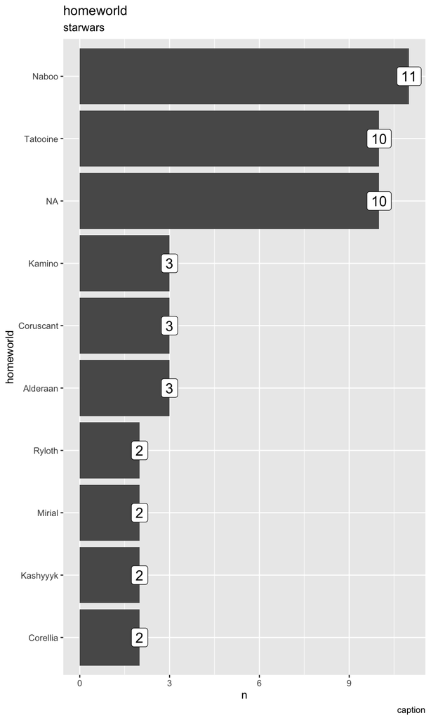

### 1.1.40 할당 연산자

##### name, height, mass, birth_year, sex, gender, homeworld, species 열을 선택한 후 starwars_1select 이라는 변수에 저장하시오

> 화살표

### 1.1.41 기술 통계량

##### starwars_1select 데이터셋에서 기술 통계량을 구하시오

> summary()

```
     name               height           mass           birth_year
 Length:87          Min.   : 66.0   Min.   :  15.00   Min.   :  8.00
 Class :character   1st Qu.:167.0   1st Qu.:  55.60   1st Qu.: 35.00
 Mode  :character   Median :180.0   Median :  79.00   Median : 52.00
                    Mean   :174.6   Mean   :  97.31   Mean   : 87.57
                    3rd Qu.:191.0   3rd Qu.:  84.50   3rd Qu.: 72.00
                    Max.   :264.0   Max.   :1358.00   Max.   :896.00
                    NA's   :6       NA's   :28        NA's   :44
     sex               gender           homeworld           species
 Length:87          Length:87          Length:87          Length:87
 Class :character   Class :character   Class :character   Class :character
 Mode  :character   Mode  :character   Mode  :character   Mode  :character
```

### 1.1.42 그룹핑과 범위값

##### starwars_1select 데이터셋에서 사회학적 성별을 기준으로(group_by) 나이(birth_year)가 가장 많은 사람과 적은 사람 1명씩 조회하시오 (나이를 알수 없는 사람은 제외할 것)

> starwars_1select, drop_na(), group_by(), filter(), range(), arrange()

```
# A tibble: 4 × 4
# Groups:   gender [2]
  name                  gender    birth_year species
  <chr>                 <chr>          <dbl> <chr>
1 Leia Organa           feminine          19 Human
2 Shmi Skywalker        feminine          72 Human
3 Wicket Systri Warrick masculine          8 Ewok
4 Yoda                  masculine        896 Yoda's species
```

### 1.1.43 고유값(1)

##### starwars_1select 데이터셋에서 등장하는 homeworld의 고유한 값은 총 몇개인가?

> dinstinct(), nrow()

```
[1] 49
```

### 1.1.44 고유값(2)

##### starwars_1select에서 homeworld의 자료형을 factor()으로 변경한 후 str() 함수를 통해 확인된 homeworld의 고유값을 위에서 확인한 결과와 비교하시오

> factor(), str()

```
tibble [87 × 8] (S3: tbl_df/tbl/data.frame)
 $ name      : chr [1:87] "Luke Skywalker" "C-3PO" "R2-D2" "Darth Vader" ...
 $ height    : int [1:87] 172 167 96 202 150 178 165 97 183 182 ...
 $ mass      : num [1:87] 77 75 32 136 49 120 75 32 84 77 ...
 $ birth_year: num [1:87] 19 112 33 41.9 19 52 47 NA 24 57 ...
 $ sex       : chr [1:87] "male" "none" "none" "male" ...
 $ gender    : chr [1:87] "masculine" "masculine" "masculine" "masculine" ...
 $ homeworld : Factor w/ 48 levels "Alderaan","Aleen Minor",..: 40 40 28 40 1 40 40 40 40 38 ...
 $ species   : chr [1:87] "Human" "Droid" "Droid" "Human" ...
```

### 1.1.45 OR 연산 (논리합)

##### sex == ‘none’ 이거나 gender가 결측치인 등장인물의 name, species, sex, gender를 출력하시오

> filter(), gender(), sex(), feminine, female

```
# A tibble: 10 × 4
   name             species sex   gender
   <chr>            <chr>   <chr> <chr>
 1 C-3PO            Droid   none  masculine
 2 R2-D2            Droid   none  masculine
 3 R5-D4            Droid   none  masculine
 4 Jek Tono Porkins <NA>    <NA>  <NA>
 5 IG-88            Droid   none  masculine
 6 Gregar Typho     <NA>    <NA>  <NA>
 7 Cordé            <NA>    <NA>  <NA>
 8 R4-P17           Droid   none  feminine
 9 Sly Moore        <NA>    <NA>  <NA>
10 BB8              Droid   none  masculine
```

### 1.1.46 AND 연산 (논리곱)

##### sex == ‘female’ 이면서, homeworld가 Naboo 혹은 Tatooine인 등장인물의 name, sex, homeworld를 출력하시오

```
# A tibble: 4 × 3
  name               sex    homeworld
  <chr>              <chr>  <chr>
1 Beru Whitesun Lars female Tatooine
2 Padmé Amidala      female Naboo
3 Shmi Skywalker     female Tatooine
4 Dormé              female Naboo
```